# Microalgae-Bacteria growth in a chemostat

We consider a model of a microalgae-bacteria coculture in a chemostat.

- **Bacteria *(Escherichia Coli, $e$)*:** constant-yield chemostat model where
  - Grows by metabolizing glucose as a substrate $s$
  - Substrate uptake is $\mu_e(s)$
  - Produces vitamin $B_1$ (thiamine) $v$
- **Microalgae *(Auxenochlorella, $c$)*:** variable-yield chemostat model where
  - Stores vitamin $v$ in cell before metabolism
  - Average cell quota is $q$, total cell quota $z=cq$
  - Vitamin uptake is $\rho(v)$
  - Grows by metabolizing stored nutrient with a growth rate $\mu_c(q)$

\begin{equation} \begin{cases} \dst &= -\frac{\mu_e(s)}{Y}e + D(\Sin - s)\\ \det &= (\mu_e(s) - D)e\\ \dvt &= \beta\mu_e(s)e -\rho(v)c - Dv\\ \dct &= (\mu_c(q) - D)c\\ \dqt &= \rho(v) - \mu_c(q)q \end{cases}\tag{AB} \end{equation}

This system can be divided into 2 systems:

The system of bacterial growth $(s,e)$ is autonomous, which means that $(v,c,q)$ do not affect it.

\begin{equation} \begin{cases} \dst &= -\frac{\mu_e(s)}{Y}e + D(\Sin - s)\\ \det &= (\mu_e(s) - D)e \end{cases}\tag{B} \end{equation}

Let $\Vin(s,e)=\frac{\beta\mu_e(s)e}{D}$, the system of microalgae corresponds to the variable-yield model, given a variable inflow of vitamin $\Vin$.

\begin{equation} \begin{cases} \dvt &= -\rho(v)c + D(\Vin(s,e) - v)\\ \dct &= (\mu_c(q) - D)c\\ \dqt &= \rho(v) - \mu_c(q)q \end{cases}\tag{A} \end{equation}

Let $z=cq$ the total stored vitamin, the microalgae system can be expressed in function of $(v,c,z)$.

\begin{equation} \begin{cases} \dvt &= -\rho(v)c + D(\Vin(s,e) - v)\\ \dct &= (\mu_c(z/c) - D)c\\ \dzt &= \rho(v)c - Dz \end{cases}\tag{A'} \end{equation}\begin{equation} \begin{cases} \dst &= -\frac{\mu_e(s)}{Y}e + D(\Sin - s)\\ \det &= (\mu_e(s) - D)e\\ \dvt &= \beta\mu_e(s)e -\rho(v)c - Dv\\ \dct &= (\mu_c(z/c) - D)c\\ \dzt &= \rho(v)c - Dz \end{cases}\tag{AB'} \end{equation}

## Conservation law

The system (AB') can be rewritten as

\begin{equation} \begin{cases} \dst &= -\frac{\mu_e(s)}{Y}e &+ D(\Sin - s)\\ \det &= \mu_e(s)e &- De\\ \dvt &= \beta\mu_e(s)e -\rho(v)c &- Dv\\ \dct &= \mu_c(z/c)c &- Dc\\ \dzt &= \rho(v)c &- Dz \end{cases}\iff \underbrace{\pmat{\dst\\ \det\\ \dvt\\ \dct\\ \dzt}}_{\dot{x}} = \underbrace{\pmat{ -\frac{1}{Y} & 0 & 0\\ 1 & 0 & 0\\ \beta & -1 & 0\\ 0 & 0 & 1\\ 0 & 1 & 0 }}_{K} \underbrace{\pmat{\mu_e(s)e\\ \rho(v)c\\ \mu_c(z/c)c}}_{v(x)} + \underbrace{\pmat{D(\Sin-s)\\-De\\-Dv\\-Dc\\-Dz}}_{x^*} \iff \boxed{\dxt = Kv(x) + x^*} \end{equation}

The left kernel of $K$ is the linear subspace of $\R^5$, indeed the left kernel of $K$ is the set of $x\in\R^5$ such that $x^t K = 0$, or equivalently $K^t x = 0$.

$$\ker(K^t) = \sset{x\in\R^5}{K^t x = 0} = \sset{x\in\R^5}{ \pmat{ -\frac{1}{Y} & 1 & \beta & 0 & 0\\ 0 & 0 & -1 & 0 & 1\\ 0 & 0 & 0 & -1 & 0} x = 0_{\R^3}} = \mathrm{span}\cb{ \pmat{Y\\1\\0\\0\\0}, \pmat{\beta Y\\0\\1\\0\\1} }$$

As $\dim(\ker(K^t))=2$, let $N\in\R^{2\times5}$ whose row space is the left kernel of $K$ therefore $NK=0$. Evidently, $N$ is not unique, we define the following $N$ $$ N = \pmat{ Y & 1 & 0 & 0 & 0\\ \beta Y & 0 & 1 & 0 & 1 }$$

Let $\sigma(t)=N x(t)$, hence $$\sigma = \pmat{ Ys + e\\ \beta Ys + v + z }$$

It follows that $\dsigmat=N\dxt=NK v(x) + Nx^* = Nx^*$ $$\dsigmat = \pmat{ YD(\Sin - s) - De\\ \beta YD(\Sin - s) - Dv - Dz } = \pmat{ YD\Sin - D(Ys + e)\\ \beta YD\Sin - D(\beta Ys + v + z)} = YD\Sin\pmat{1\\\beta} - D\sigma$$

Let $\sigmain = \pmat{Y\Sin\\\beta Y\Sin}$ therefore $\boxed{\dsigmat(t) = D(\sigmain - \sigma(t))}$ which has a unique solution for a given initial condition $\sigma(0)\in\R^2$, $\sigma(t) = \sigmain + e^{-Dt}(\sigma(0) - \sigmain)$.

It follows that $\sigma(t)$ converges (exponentially) to $\sigmain$ and that $\dsigmat=0\iff\sigma=\sigmain$. Which means that the set $\Sigma = \sset{x\in\R_+^5}{Nx = \sigmain} = \sset{x\in\R_+^5}{N\dxt = 0}$ is an **exponentially attracting invariant set**.

Let's expand the expression of $\Sigma$ $$\Sigma = \sset{(s,e,v,c,z)\in\R_+^5}{ \begin{array}{l} Ys + e = Y\Sin\\ \beta Ys + v + z = \beta Y\Sin \end{array} }$$

We notice that $\Sigma$ is an affine subspace of $\R^5$ with $\dim(\Sigma) = 3$. By considering $x\in\Sigma$, the problem (AB') reduces to 3 dimensions.

\begin{equation} \begin{cases} \det &= \pp{\mu_e(s) - D}e\\ \dct &= \pp{\mu_c\pp{\frac{z}{c}} - D}c\\ \dzt &= \rho(v)c - Dz\\ \end{cases}\quad\text{with}~ \begin{cases} s = \Sin-\frac{e}{Y}\\ v = \beta e - z \end{cases}\tag{C} \end{equation}

Other formulations are also possible, for example:

\begin{equation} \begin{cases} \dst &= (D-\mu_e(s))(\Sin - s)\\ \dct &= (\mu_c(z/c) - D)c\\ \dzt &= \rho(v)c - Dz\\ \end{cases}\quad\text{with}~ \begin{cases} e = Y(\Sin - s)\\ v = \beta Y(\Sin - s) - z \end{cases}\tag{C'} \end{equation}

## Equilibria

Equilibria are points of the system where $\dxt=0$, which in this system lie on $\Sigma$ since $\dxt=0\implies N\dxt=0$. Theoretically, equilibria of (C) might not all be equilibria of (AB'). Nevertheless, it is reasonable to find equilibria in (C) since $\Sigma$ since all trajectories of the system (AB') are asymptotic to $\Sigma$.

Since we have studied in detail both constant-yield and variable-yield systems, we can make use of the previous studies, let's recall their equilibria.

### Constant-yield equilibria

We remind that the constant yield model (B) has the following equilibria

|  | $$ D < \mu_e(\Sin) $$ | $$ D > \mu_e(\Sin) $$ |
| --- | --- | --- |
| $B_0$ | unstable | attractor |
| $B_1$ | attractor | undefined |

with

- $B_0 = (\Sin, 0)$ known as the washout equilibrium
- $B_1 = (s^*, e^*)$ as the equilibrium with positive biomass with $\begin{cases} s^*=\mu_e^{-1}(D)\\ e^*=Y(\Sin - s^*)=Y(\Sin - \mu_e^{-1}(D)) \end{cases}$

### Variable-yield equilibria

The variable yield model (A') has the following the equilibria

|  | $$ D < \phi(\Vin) $$ | $$ D > \phi(\Vin) $$ |
| --- | --- | --- |
| $A_0$ | unstable | attractor |
| $A_1$ | attractor | undefined |

where $\phi:v\mapsto d$ is an increasing function whose inverse is defined as $\phi^{-1}(d) = \rho^{-1}(d\mu_c^{-1}(d))$ with

- $A_0 = (\Vin, 0, 0)$ known as the washout equilibrium
- $A_1 = (v^*, e^*, z^*)$ as the equilibrium with positive biomass with $\begin{cases} v^*=\phi^{-1}(D)\\ c^*=\frac{z^*}{\mu_c^{-1}(D)}=\frac{\Vin - v^*}{\mu_c^{-1}(D)}\\ z^*=\Vin - v^* \end{cases}$

### Microalgae-Bacteria equilibria

We expect the equilibria of (AB') to be the cartesian product of the equilibria points of both models

|  | $ B_0 $ | $ B_1 $ |
| --- | --- | --- |
| $A_0$ | $ E_{0,0} $ | $ E_{1,0} $ |
| $A_1$ | $ E_{0,1} $ | $ E_{1,1} $ |

The system (B) is autonomous, therefore the equilibria are exactly those of the constant yield model

- $E_{0,\cdot} = (\Sin,0,\cdot,\cdot,\cdot)$
- $E_{1,\cdot} = (s^*,e^*,\cdot,\cdot,\cdot)$

Nevertheless, the interaction between the bacteria and the microalgae in this model is the vitamin inflow $\Vin(s,e)$ which is variable, unlike in (A'). Consequently, the variables $(v,c,z)$ here depend on $(s,e)$.

- In the case of bacteria washout $E_{0,\cdot}$, the microalgae system (A') is extinguished since there is no vitamin inflow $\Vin(\Sin,0)=0$. Therefore, $E_{0,0} = E_{0,1} = (\Sin,0,0,0,0) = E_0$ This is the sole equilibrium of the system if $D > \mu_e(\Sin)$, in which this equilibrium is asymptotically stable (attractor).
- At the equilibrium of bacteria with positive biomass, the vitamin inflow for the microalgae system is considered constant, $\Vin^*=\Vin(s^*,e^*)=\frac{\beta\mu_e(s^*)e^*}{D}=\beta e^*=\beta Y(\Sin - s^*)$, in this case, the microalgae system has the following equilibria:
  - $E_{1,0}=(s^*,e^*,\Vin^*,0,0)$
  - $E_{1,1}=(s^*,e^*,v^*,c^*,z^*)$ if $D < \phi(\Vin^*)$ with $\begin{cases} v^*=\phi^{-1}(D)\\ c^*=\frac{z^*}{\mu_c^{-1}(D)}=\frac{\Vin^* - v^*}{\mu_c^{-1}(D)}\\ z^*=\Vin^* - v^* \end{cases}$

Therefore, the system (AB') has up to 3 equilibria, whose existence and stability depend on $D, \Sin$ and $\Vin^*$.

However, $\Vin^*=\beta Y(\Sin - \mu_e^{-1}(D))$ therefore $\Vin^*$ can be expressed as a function of $D$ and $\Sin$.

Indeed, $E_{1,1}$ is well-defined for $D < \phi(\Vin^*)$

\begin{align*} D &< \phi(\Vin^*)\\ \phi^{-1}(D) &< \Vin^*\\ \phi^{-1}(D) &< \beta Y(\Sin - \mu_e^{-1}(D))\\ \mu_e^{-1}(D) + \frac{\phi^{-1}(D)}{\beta Y} &< \Sin \end{align*}

let $\psi:s\mapsto d$ an increasing function whose inverse is defined as $\psi^{-1}(d) = \mu_e^{-1}(d) + \frac{\phi^{-1}(d)}{\beta Y}$, therefore $D < \phi(\Vin^*) \iff D < \psi(\Sin)$.

Moreover, from the definition $\psi$, we have $\forall d>0, \psi^{-1}(d) > \mu_e^{-1}(d)$ therefore $\forall s>0, \psi(s) < \mu_e(s)$. In particular, $\psi(\Sin) < \mu_e(\Sin)$, we can conclude the following about the system's equilibria:

|  | $$ D < \psi(\Sin) $$ | $$ \psi(\Sin) < D < \mu_e(\Sin) $$ | $$ D > \mu_e(\Sin) $$ |
| --- | --- | --- | --- |
| $E_0$ | unstable | unstable | attractor |
| $E_{1,0}$ | unstable | attractor | undefined |
| $E_{1,1}$ | attractor | undefined | undefined |

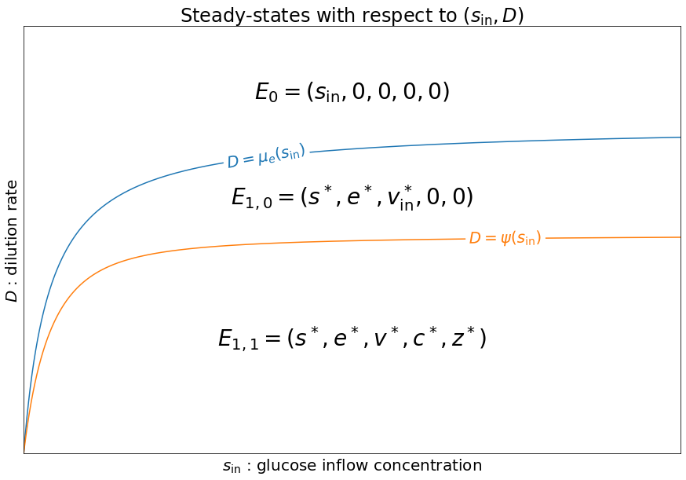

```python
%matplotlib inline
%run ../ABmodel.py
import numpy as np
import matplotlib.pyplot as plt
from matplotlib import rcParams
from labellines import labelLines
rcParams.update({'font.size': 20})

#d = np.arange(0.01, 3, 0.01)
def get_d(func, smax=10, dstep=0.1, dmax=1, stol=2, **kw):
    s = func(np.linspace(dstep, dmax, 50), **kw)
    # s too big or negative s --> decrement d
    if np.any(s < 0) or (s[-1] - smax) > stol:
        return get_d(func, smax=smax, dstep=dstep, dmax=dmax-dstep, stol=stol, **kw)
    # s too small --> increment d with smaller step
    if (smax - s[-1]) > stol:
        dstep /= 2
        return get_d(func, smax=smax, dstep=dstep, dmax=dmax+dstep, stol=stol, **kw)
    # s close enough
    return np.arange(dstep, dmax, dstep)

plt.figure(figsize=(15,10), facecolor='white')
ax = plt.gca()

d = get_d(mu_e_inv, smax=6, dstep=0.01, dmax=2, stol=0.1, **params)
plt.plot(mu_e_inv(d, **params), d, label='$D=\\mu_e(s_\\mathrm{{in}})$')
d = get_d(psi_inv, smax=6, dstep=0.01, dmax=2, stol=0.1, **params)
plt.plot(psi_inv(d, **params), d, label='$D=\\psi(s_\\mathrm{{in}})$')
ax.set_xlabel('$s_\\mathrm{{in}}$ : glucose inflow concentration')
ax.set_ylabel('$D$ : dilution rate')
ax.set_title('Steady-states with respect to $(s_\\mathrm{in}, D)$')
labelLines(ax.get_lines(), zorder=2.5, backgroundcolor="white")

text_kw = dict(ha='center', va='center', fontsize=28)
plt.text(2.5, 1.10, '$E_0 = (s_\\mathrm{in},0,0,0,0)$', **text_kw)
plt.text(2.5, 0.78, '$E_{1,0} = (s^*,e^*,v_\\mathrm{in}^*,0,0)$', **text_kw)
plt.text(2.5, 0.35, '$E_{1,1} = (s^*,e^*,v^*,c^*,z^*)$', **text_kw)
ax.set_ylim(0, 1.3)
ax.set_xlim(0, 5)
ax.tick_params(axis='both', which='both',
               left=False, bottom=False, labelleft=False, labelbottom=False)

plt.show();
```